# Deciding on number of event clusters to use at Hungerford by mapping clusters onto yields and CQ patterns

Dustin Kincaid

11/11/2021

### Objective

##### Create key figures for paper summarizing all results of SOM clustered flux regimes on event NO3, SRP, and turbidity yields from Hungerford and Wade Brooks.

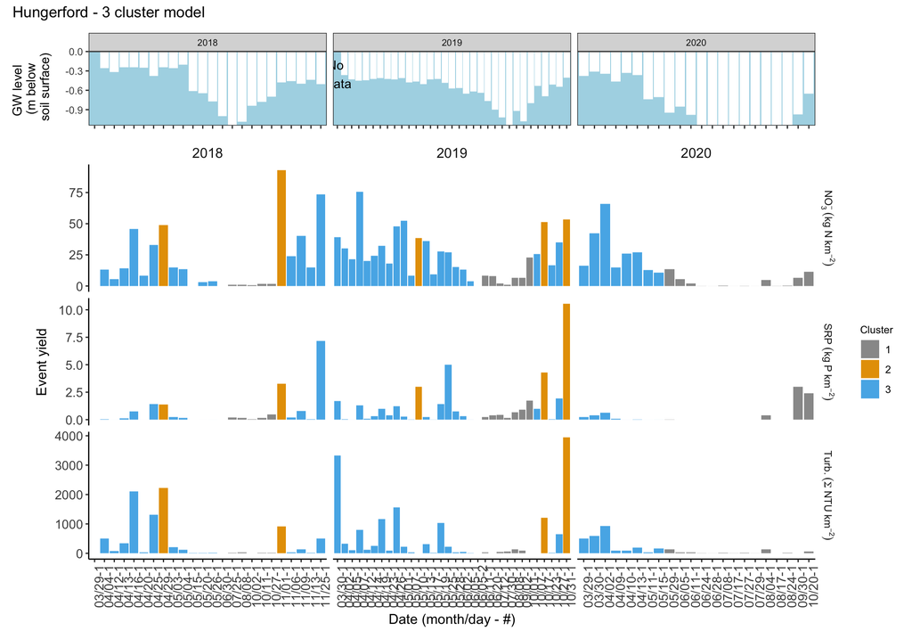

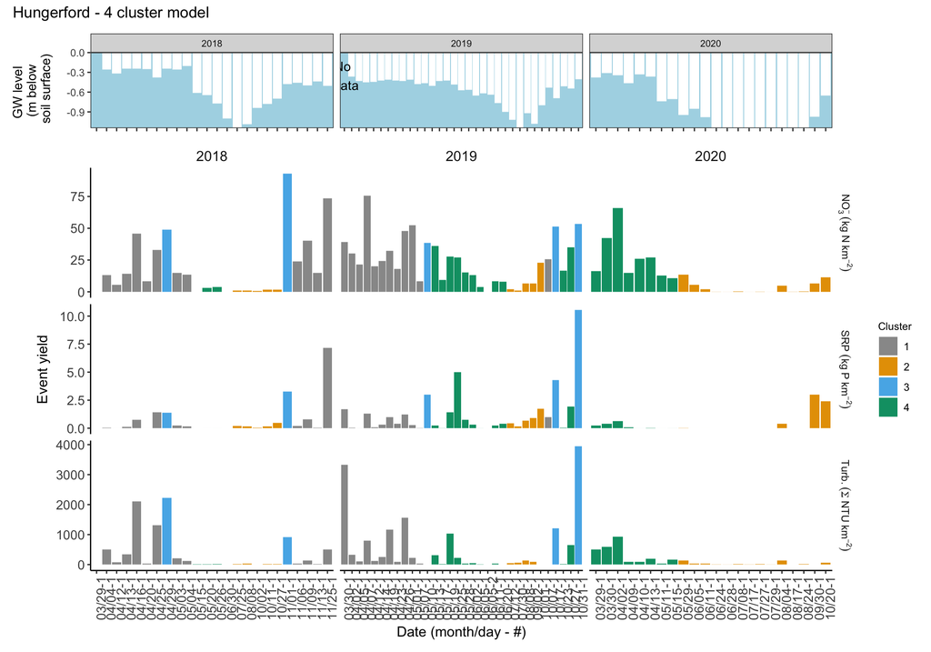

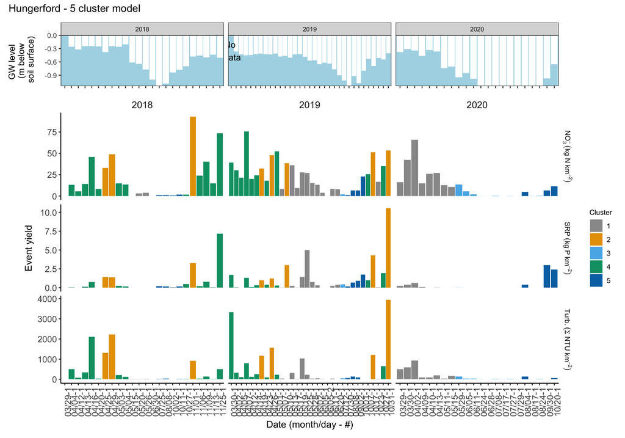

Time series of water yields colored by cluster. 2017 data not shown because only a few events in fall. The white bars in the upper groundwater level plot indicate the groundwater depth below the soil surface. Keep in mind that a different SOM was created for each site x variable (e.g., NO3, SRP) combo; thus, the clusters may not have the same properties for each site x variable combination.

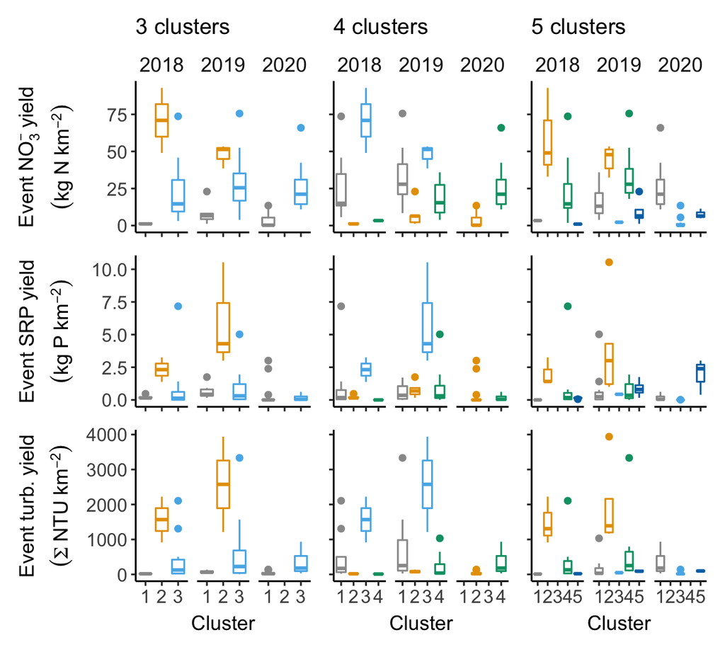

### Ice-free season yields attributed to each cluster

#### Not showing 2017 because we only captured events in the last 1/3 of the year

#### I wasn’t going to show 2020 here, but I think we got the sensors out at a similar time as previous years; at Wade we didn’t

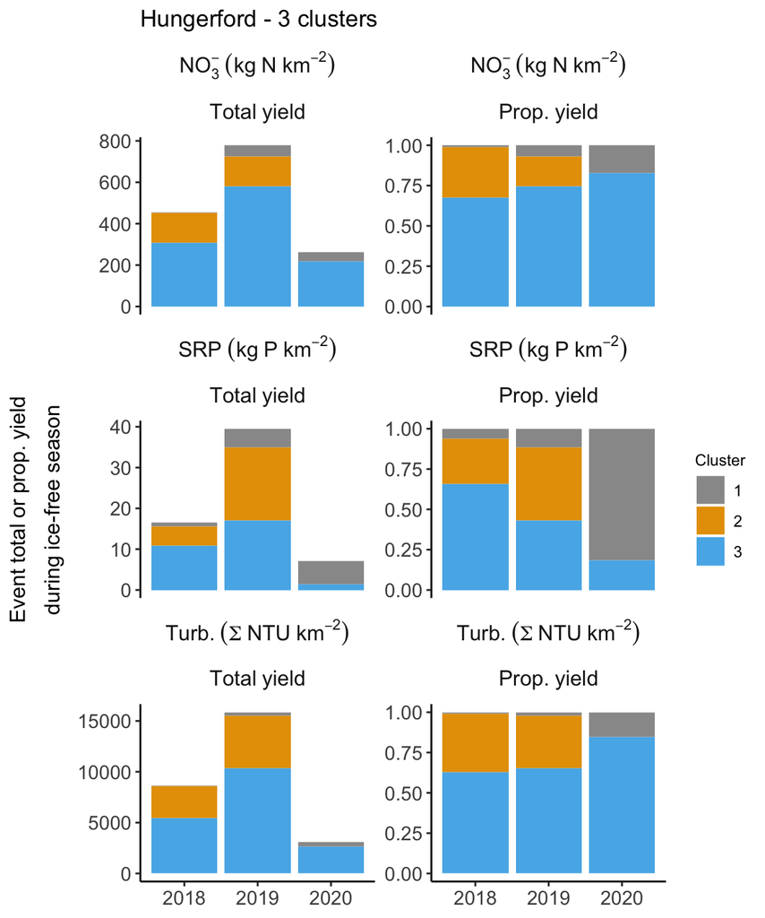

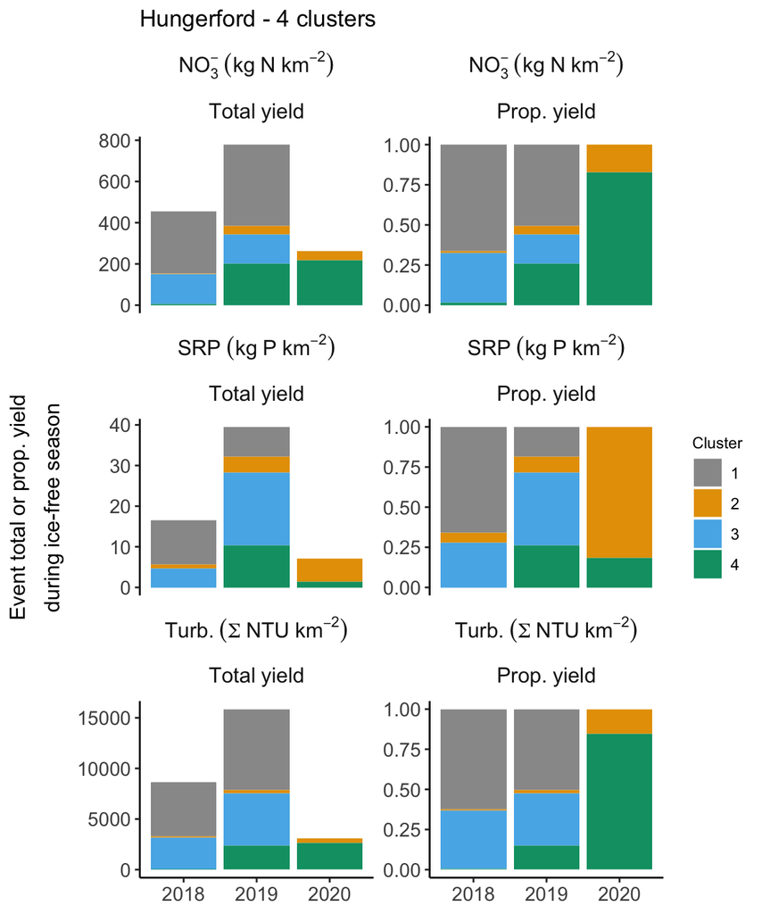

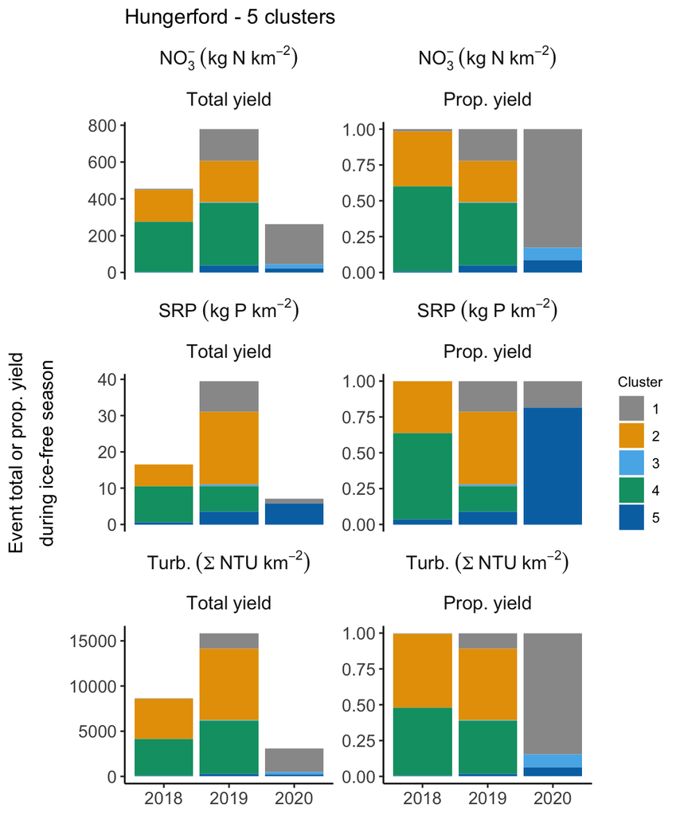

Total ice-free season water yield attributed to each cluster. Keep in mind that a different SOM was created for each site x variable (e.g., NO3, SRP) combo; thus, the clusters may not have the same properties for each site x variable combination.

### Relationship between event NO3, SRP, or turbidity yield and event water yield for each season

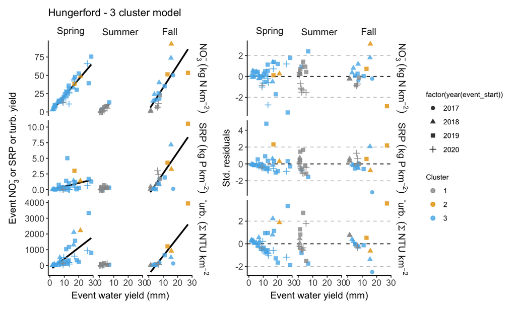

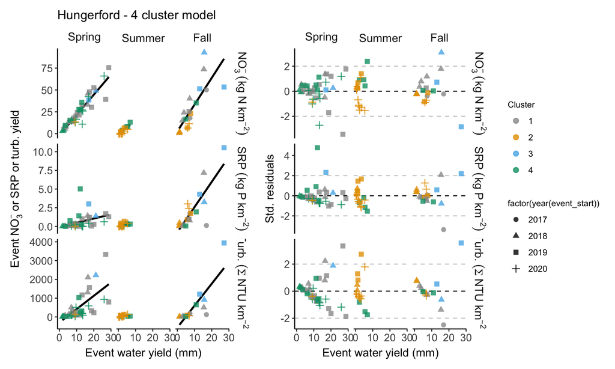

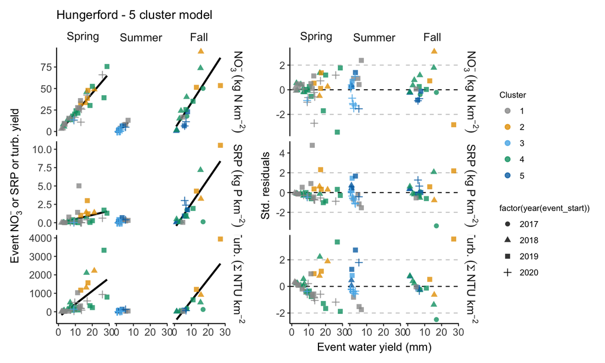

Need to remove outliers from regressions.

### Event NO3 to SRP yield ratios

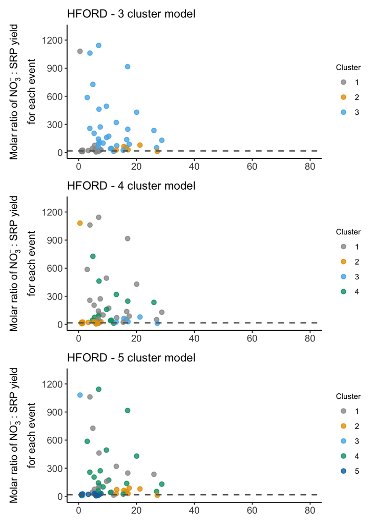

Molar ratio of NO3 to SRP yield for each event. The dashed horizontal line shows the 16:1 molar N:P ratio.

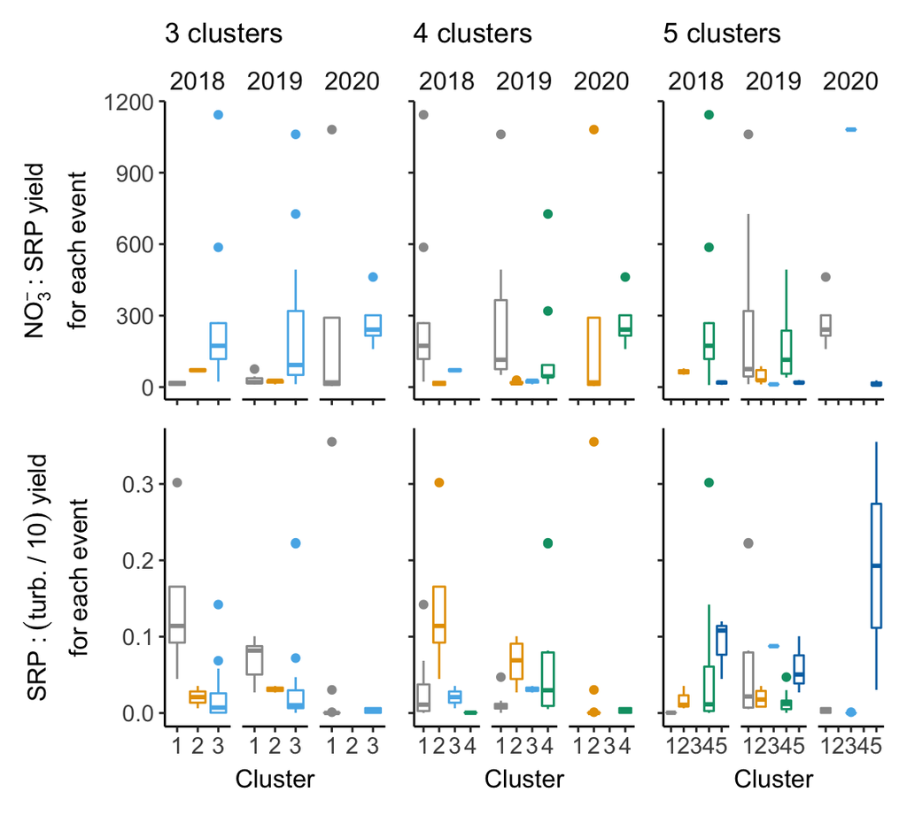